# Chapter 9 Building the Regression Model I

Bryan Goodrich

2015-08-08

# Chapter 9 – Building the Regression Model I: Model Selection and Validation

## Load the data sets

```r
library(MPV)  # For PRESS wrapper function
library(leaps)  # bestsubsets

data("CH09TA01", package = "ALSM")
data("CH09TA05", package = "ALSM")
```

## Input the Surgical Unit Data

```r
.data <- CH09TA01
names(.data) <- c(paste("X", 1:8, sep = ""), "Y" , "lnY")
data.names <- c("Bloodclot", "Progindex", "Enzyme", "Liver",
                "Age", "Gender", "Alc.Mod", "Alc.Heavy",
                "Survival", "LnSurvival")
```

## TABLE 9.1 (p 350)

#### Potential Predictor Variables and Response Variable–Surgical Unit Example

```r
{
  print(head(.data))
  cat("... \n")
  print(tail(.data))
}
```

```
##    X1 X2  X3   X4 X5 X6 X7 X8    Y   lnY
## 1 6.7 62  81 2.59 50  0  1  0  695 6.544
## 2 5.1 59  66 1.70 39  0  0  0  403 5.999
## 3 7.4 57  83 2.16 55  0  0  0  710 6.565
## 4 6.5 73  41 2.01 48  0  0  0  349 5.854
## 5 7.8 65 115 4.30 45  0  0  1 2343 7.759
## 6 5.8 38  72 1.42 65  1  1  0  348 5.852
## ...
##     X1 X2  X3   X4 X5 X6 X7 X8    Y   lnY
## 49 5.1 67  77 2.86 66  1  0  0  581 6.365
## 50 3.9 82 103 4.55 50  0  1  0 1078 6.983
## 51 6.6 77  46 1.95 50  0  1  0  405 6.005
## 52 6.4 85  40 1.21 58  0  0  1  579 6.361
## 53 6.4 59  85 2.33 63  0  1  0  550 6.310
## 54 8.8 78  72 3.20 56  0  0  0  651 6.478
```

## Diagnostic Results Not Shown in Book (p 351)

Included here are the stem-and-leaf plots for each of the predictor variables chosen to be used at this time (i.e., the first four). Also included is the scatterplot matrix and correlation matrix.

Since I think the boxplot is more visually telling than the stem-and-leaf plots, I have also included a 2x2 graphics output of the boxplots for each of the predictor variables.

```r
with(.data,
{
    stem(X1, 2)
    stem(X2, 4)
    stem(X3, 4)
    stem(X4)
    cor(.data[1:4])
})
```

```
##
##   The decimal point is at the |
##
##    2 | 6
##    3 | 244
##    3 | 67779
##    4 | 3
##    4 | 588
##    5 | 0112222344
##    5 | 678888888
##    6 | 003344
##    6 | 5556777
##    7 | 344
##    7 | 78
##    8 |
```

[output cut: 119 more lines]

```
##          X1       X2       X3     X4
## X1  1.00000  0.09012 -0.14963 0.5024
## X2  0.09012  1.00000 -0.02361 0.3690
## X3 -0.14963 -0.02361  1.00000 0.4164
## X4  0.50242  0.36903  0.41642 1.0000
```

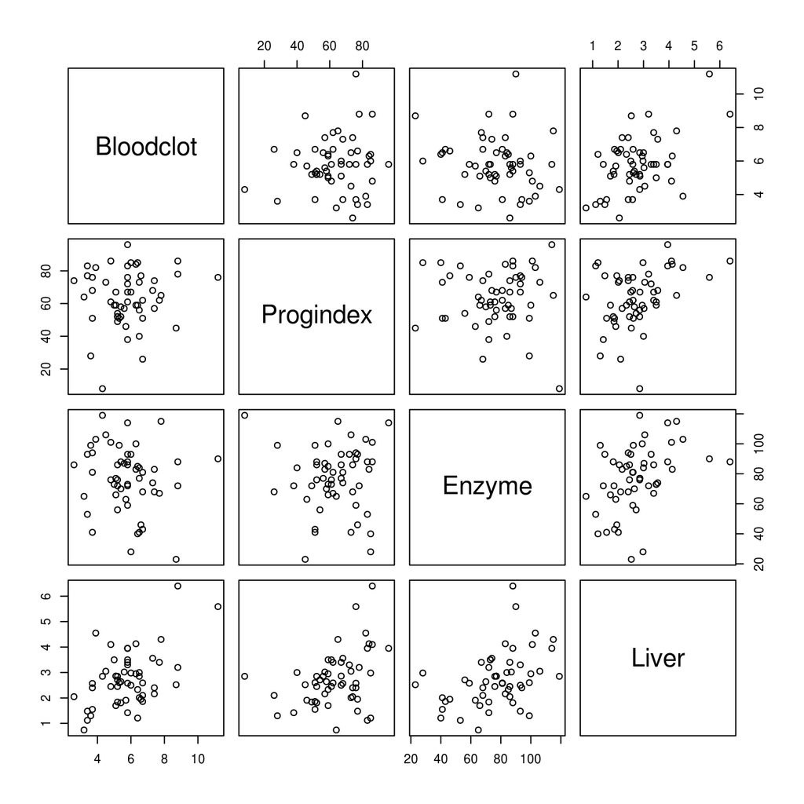

```r
pairs(.data[1:4], labels = data.names[1:4])
```

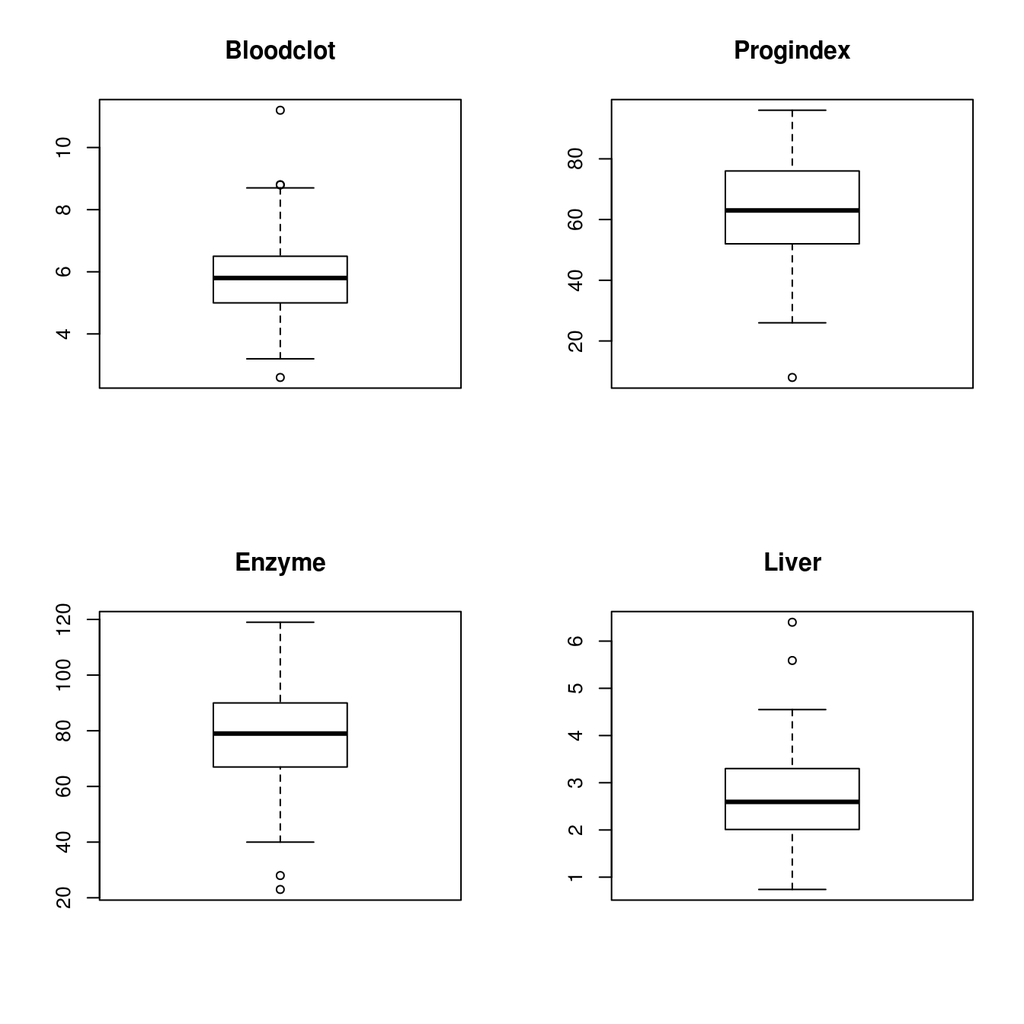

```r
with(.data,
{
    par(mfrow = c(2, 2))
    boxplot(X1, main = "Bloodclot")
    boxplot(X2, main = "Progindex")
    boxplot(X3, main = "Enzyme"   )
    boxplot(X4, main = "Liver"    )
})
```

## FIGURE 9.2 (p 351)

#### Some Preliminary Residual Plots–Surgical Unit Example

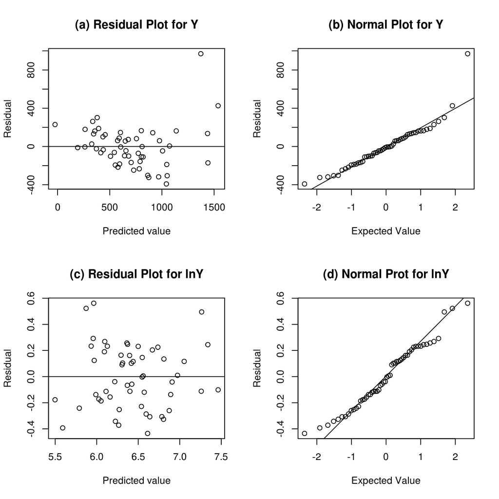

```r
par(mfrow = c(2, 2))

fit <- lm(Y ~ X1 + X2 + X3 + X4, .data)
plot(fitted(fit), resid(fit), xlab = "Predicted value", ylab = "Residual")
title("(a) Residual Plot for Y")
abline(0, 0)

qqnorm(resid(fit), xlab = "Expected Value", ylab = "Residual", main = "")
qqline(resid(fit))
title("(b) Normal Plot for Y")

fit <- lm(lnY ~ X1 + X2 + X3 + X4, .data)
plot(fitted(fit), resid(fit), xlab = "Predicted value", ylab = "Residual")
title("(c) Residual Plot for lnY")
abline(0, 0)

qqnorm(resid(fit), xlab = "Expected Value", ylab = "Residual", main = "")
qqline(resid(fit))
title("(d) Normal Prot for lnY")
```

## FIGURE 9.3 (p 352)

#### Scatter Plot Matrix and Correlation Matrix when Response Variable is lnY–Surgical Unit Example

```r
cor(model.frame(fit))
```

```
##        lnY       X1       X2       X3     X4
## lnY 1.0000  0.24619  0.46994  0.65389 0.6493
## X1  0.2462  1.00000  0.09012 -0.14963 0.5024
## X2  0.4699  0.09012  1.00000 -0.02361 0.3690
## X3  0.6539 -0.14963 -0.02361  1.00000 0.4164
## X4  0.6493  0.50242  0.36903  0.41642 1.0000
```

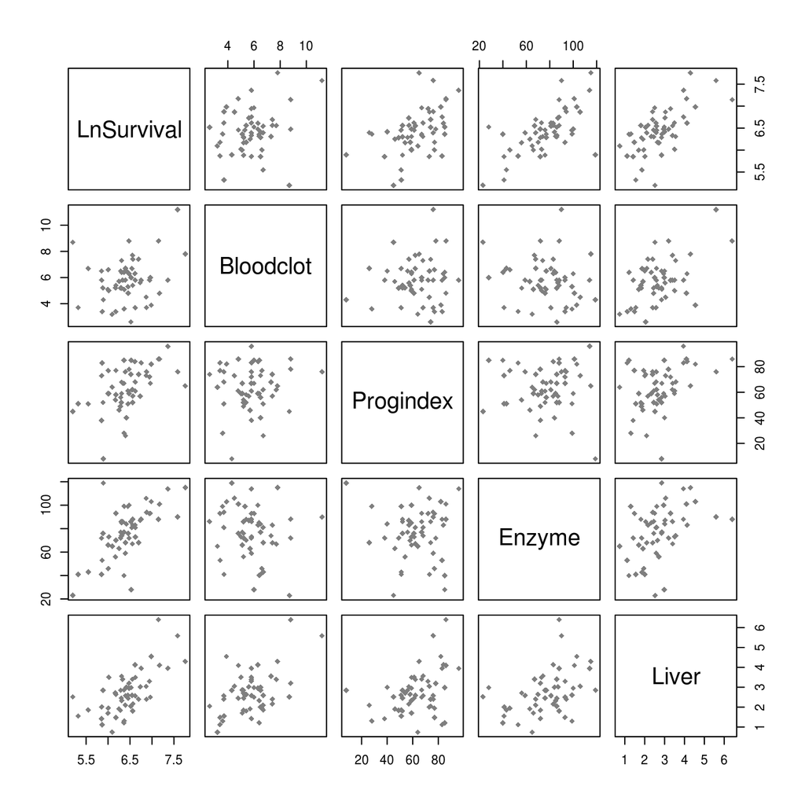

```r
pairs(model.frame(fit), labels = data.names[c(10, 1:4)], pch = 18, col = "grey50")
```

## TABLE 9.2 (p 353)

#### Selected Criteria Values for Model Selection for All Possible Regression Models–Surgical Unit Example

R contains many ways by which to access the relevant selection criteria values. There is also the regsubsets function in the “leaps” library that calculates most of these values for all the subsets you specify. However, if you desired a way to obtain the values for each combination of models, then you could use an algorithm similar to the follow:

```
    models <- list()
    for(i in seq(p)) models[[i]] <- t(combn(1:p, i))
    models <- lapply(models, function(set) {apply(set, 1, function(row) lm(y ~ ., data[row]))})
    unlist(lapply(models, function(set) lapply(set, sumfun)))
```

The requirements are that `p` is the number of parameters to combine, the data needs to be arranged so the first columns are the predictors, `y` names the response variable (use transform on the full model’s frame), and `sumfun` names either your own or some other defined function to operate on lm objects. In this case, there are functions for `AIC` (*stats*), `PRESS` (*MPV*), and others. Since the `models` object contains a list of lists of the possible combinations of `p` predictors, the use of `unlist` is to return the raw values as a vector. Then you can `cbind` them into a new dataframe to summarize results. Note, for BIC results set the `AIC` k value to `log(n)`.

Since `regsubsets` provides most of the criteria in `TABLE 9.2`, I will simply make use of that output. I will also provide some plotting with `regsubsets`. Since this procedure will be repeated a few times, I will make a “wrapper” function to generate the table of interest.

The plots of `regsubsets` produces shaded squares, where shaded means that variable is included in the model. See the help pages for plot.regsubsets for details. This approach can be useful when a corresponding table is large.

```r
best <- function(model, ...)
{
  subsets <- regsubsets(formula(model), model.frame(model), ...)
  subsets <- with(summary(subsets),
                  cbind(p = as.numeric(rownames(which)), which, rss, rsq, adjr2, cp, bic))

  return(subsets)
}

round(best(fit, nbest = 4), 4)
```

```
##   p (Intercept) X1 X2 X3 X4    rss    rsq  adjr2     cp     bic
## 1 1           1  0  0  1  0  7.332 0.4276 0.4166  66.49 -22.146
## 1 1           1  0  0  0  1  7.409 0.4215 0.4104  67.71 -21.581
## 1 1           1  0  1  0  0  9.979 0.2208 0.2059 108.56  -5.498
## 1 1           1  1  0  0  0 12.031 0.0606 0.0425 141.16   4.602
## 2 2           1  0  1  1  0  4.312 0.6633 0.6501  20.52 -46.814
## 2 2           1  0  0  1  1  5.130 0.5995 0.5838  33.50 -37.443
## 2 2           1  1  0  1  0  5.781 0.5486 0.5309  43.85 -30.989
## 2 2           1  0  1  0  1  6.622 0.4830 0.4627  57.21 -23.654
## 3 3           1  1  1  1  0  3.108 0.7573 0.7427   3.39 -60.502
## 3 3           1  0  1  1  1  3.614 0.7178 0.7009  11.42 -52.365
## 3 3           1  1  0  1  1  4.968 0.6121 0.5889  32.93 -35.186
## 3 3           1  1  1  0  1  6.570 0.4870 0.4562  58.39 -20.089
## 4 4           1  1  1  1  1  3.084 0.7592 0.7396   5.00 -56.942
```

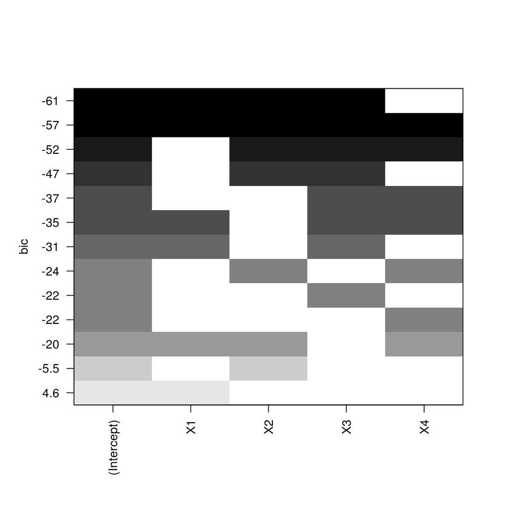

```r
subsets <- regsubsets(formula(fit), model.frame(fit), nbest = 4)

plot(subsets)
```

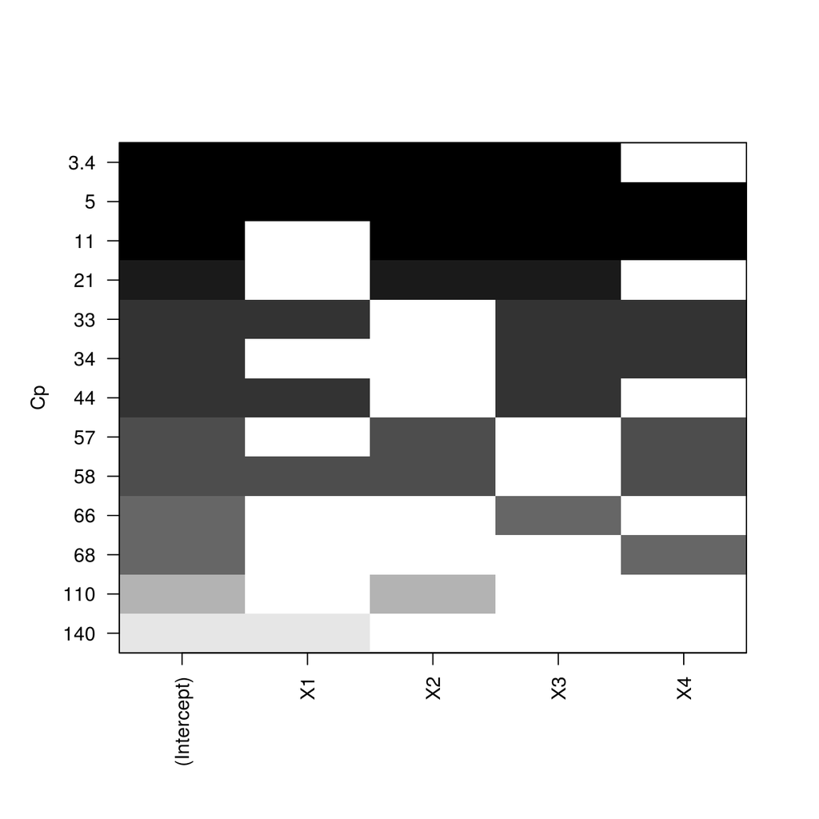

```r
plot(subsets, scale = "Cp")
```

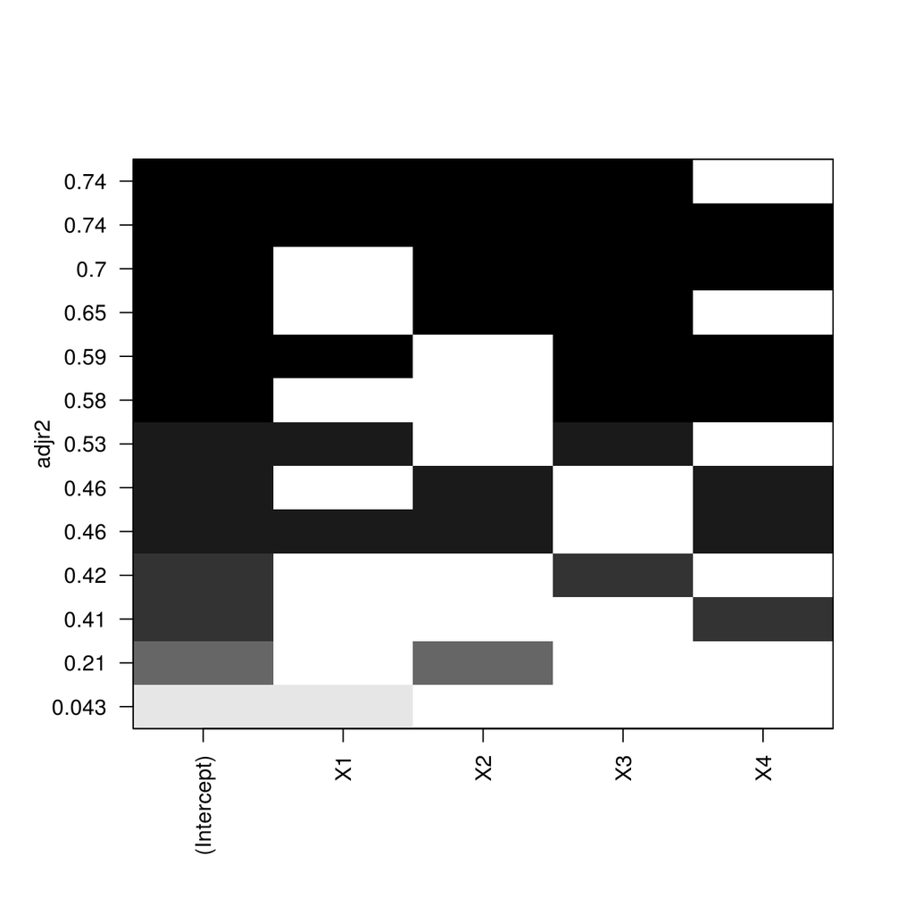

```r
plot(subsets, scale = "adjr2")
```

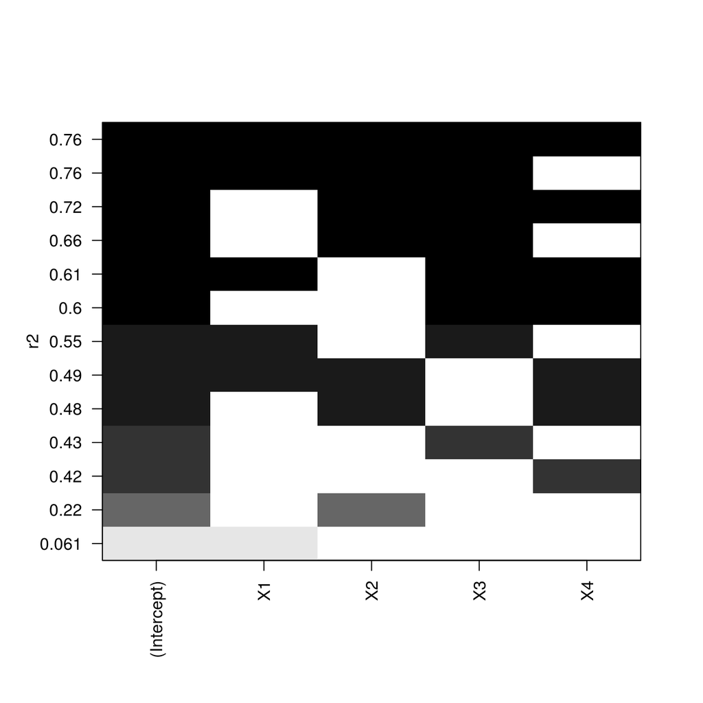

```r
plot(subsets, scale = "r2")
```

## FIGURE 9.4 (p 356)

#### Plot of Variables Selection Criteria–Surgical Unit Example

The 1:4 is hard-coded into the ‘lines’ calls. This could be automated with something like this:

> `seq(unique(x[, 'p']))`

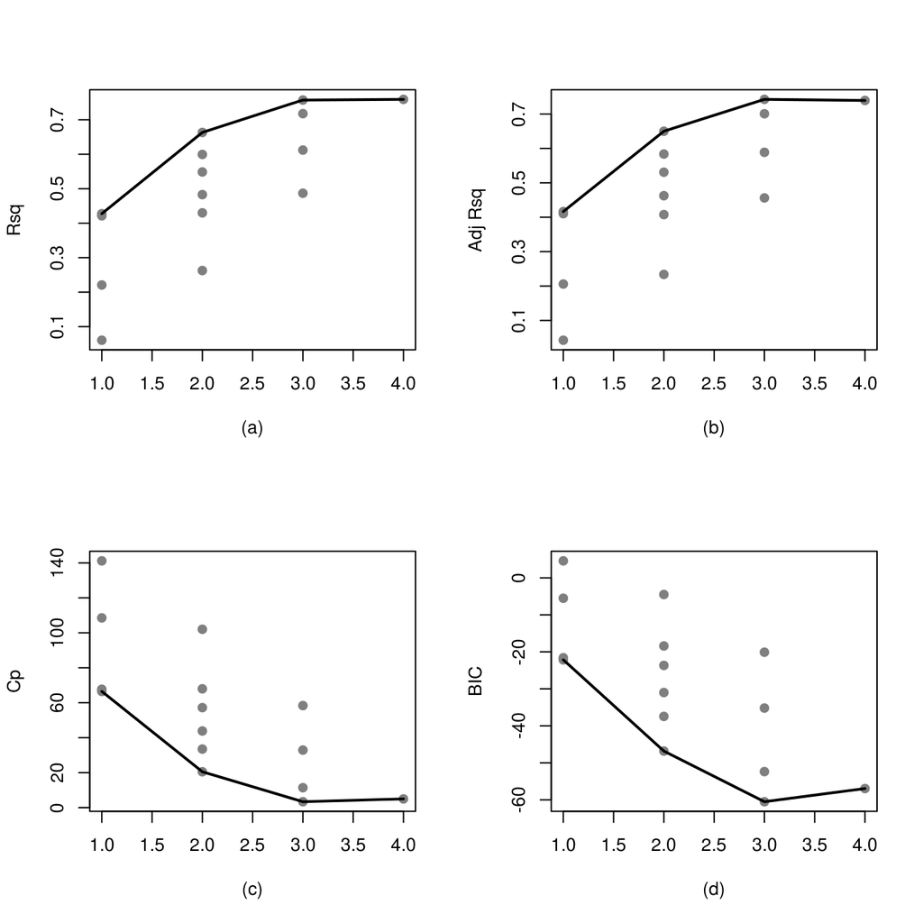

```r
x <- best(fit, nbest = 6)

par(mfrow = c(2, 2), pch = 19)

plot(rsq ~ p, x,   xlab = "(a)", ylab = "Rsq", col = "gray50")
lines(1:4, tapply(x[, "rsq"], x[, "p"], max), lwd = 2)

plot(adjr2 ~ p, x, xlab = "(b)", ylab = "Adj Rsq", col = "gray50")
lines(1:4, tapply(x[, "adjr2"], x[, "p"], max), lwd = 2)

plot(cp ~ p, x,    xlab = "(c)", ylab = "Cp", col = "gray50")
lines(1:4, tapply(x[, "cp"], x[, "p"], min), lwd = 2)

plot(bic ~ p, x,   xlab = "(d)", ylab = "BIC", col = "gray50")
lines(1:4, tapply(x[, "bic"], x[, "p"], min), lwd = 2)
```

## FIGURE 9.5 (p 362)

#### Plot of Variable Selection Criteria with All Eight Predictors–Surgical Unit Example

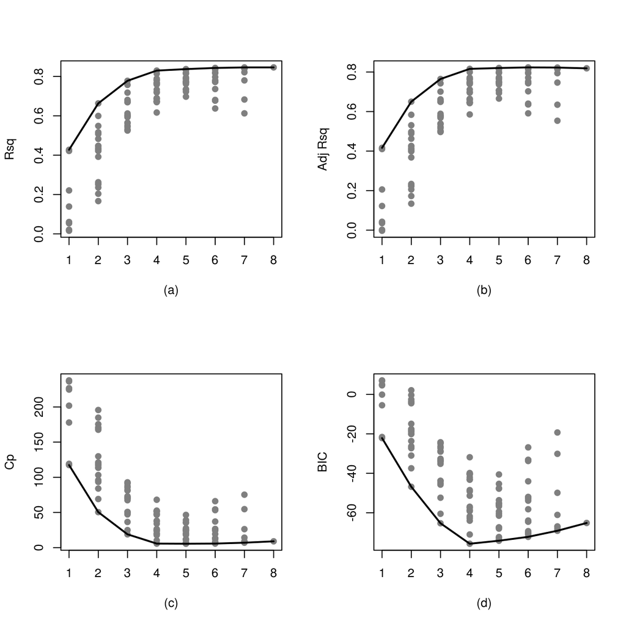

```r
fit <- lm(lnY ~ X1 + X2 + X3 + X4 + X5 + X6 + X7 + X8, .data)
x   <- best(fit, nbest = 20)

par(mfrow = c(2, 2), pch = 19)
plot(rsq ~ p, x, xlab = "(a)", ylab = "Rsq", col = "gray50")
lines(1:8, tapply(x[, "rsq"], x[, "p"], max), lwd = 2)

plot(adjr2 ~ p, x, xlab = "(b)", ylab = "Adj Rsq", col = "gray50")
lines(1:8, tapply(x[, "adjr2"], x[, "p"], max), lwd = 2)

plot(cp ~ p, x, xlab = "(c)", ylab = "Cp", col = "gray50")
lines(1:8, tapply(x[, "cp"], x[, "p"], min), lwd = 2)

plot(bic ~ p, x, xlab = "(d)", ylab = "BIC", col = "gray50")
lines(1:8, tapply(x[, "bic"], x[, "p"], min), lwd = 2)
```

## FIGURE 9.6 (p 363)

#### Output for “Best” Two Subsets for Each Subset Size–Surgical Unit Example

```r
round(best(fit, nbest = 2), 4)  # Fundamentally same info as in TABLE 9.3
```

```
##   p (Intercept) X1 X2 X3 X4 X5 X6 X7 X8   rss    rsq  adjr2      cp    bic
## 1 1           1  0  0  1  0  0  0  0  0 7.332 0.4276 0.4166 117.409 -22.15
## 1 1           1  0  0  0  1  0  0  0  0 7.409 0.4215 0.4104 119.171 -21.58
## 2 2           1  0  1  1  0  0  0  0  0 4.312 0.6633 0.6501  50.472 -46.81
## 2 2           1  0  0  1  1  0  0  0  0 5.130 0.5995 0.5838  69.132 -37.44
## 3 3           1  0  1  1  0  0  0  0  1 2.843 0.7780 0.7647  18.915 -65.33
## 3 3           1  1  1  1  0  0  0  0  0 3.108 0.7573 0.7427  24.980 -60.50
## 4 4           1  1  1  1  0  0  0  0  1 2.179 0.8299 0.8160   5.751 -75.70
## 4 4           1  0  1  1  1  0  0  0  1 2.377 0.8144 0.7993  10.267 -71.01
## 5 5           1  1  1  1  0  0  1  0  1 2.082 0.8374 0.8205   5.541 -74.17
## 5 5           1  1  1  1  0  1  0  0  1 2.103 0.8358 0.8187   6.018 -73.63
## 6 6           1  1  1  1  0  1  1  0  1 2.005 0.8434 0.8234   5.787 -72.21
## 6 6           1  1  1  1  0  0  1  1  1 2.060 0.8392 0.8187   7.029 -70.76
## 7 7           1  1  1  1  0  1  1  1  1 1.972 0.8460 0.8226   7.029 -69.12
## 7 7           1  1  1  1  1  1  1  0  1 2.003 0.8436 0.8198   7.735 -68.28
## 8 8           1  1  1  1  1  1  1  1  1 1.971 0.8461 0.8188   9.000 -65.17
```

## FIGURE 9.7 (p 366)

#### Forward Stepwise Regression Output–Surgical Unit Example

R comes with a number of stepwise functions. The most basic of these is `step` (*base*). There is also `stepAIC` (*MASS*), which provides for a wider range of object classes. Also, there is `stepwise` (*Rcmdr*) that appears to pose an easier interface to using the BIC instead of AIC calculation. As above, you need to define the `k` parameter appropriately to use the BIC in your stepwise regression methods. Additionally, there’s `mle.stepwise` (*wle*). We will focus on only using *base* functions here.

If one wanted to run the process themselves, there exists the intuitive functions `add1` and `drop1` that provide for an easy way to accomplish that. They provide RSS and AIC to make comparisons at each step. For repeated use, the `x` parameter can be passed a model matrix, but no checks are done on its validity. Read their help files for details.

```r
BIC <- log(nrow(model.frame(fit)))
fit <- lm(lnY ~ X1 + X2 + X3 + X4 + X5 + X6 + X7 + X8, .data)  # Full Model
step(fit, direction = "forward")      # AIC = -160.77 Drop None
```

```
## Start:  AIC=-160.8
## lnY ~ X1 + X2 + X3 + X4 + X5 + X6 + X7 + X8
```

```
##
## Call:
## lm(formula = lnY ~ X1 + X2 + X3 + X4 + X5 + X6 + X7 + X8, data = .data)
##
## Coefficients:
## (Intercept)           X1           X2           X3           X4
##     4.05052      0.06851      0.01345      0.01495      0.00802
##          X5           X6           X7           X8
##    -0.00357      0.08421      0.05786      0.38838
```

```r
step(fit, dir = "forward",  k = BIC)  # BIC = -142.87 Drop None
```

```
## Start:  AIC=-142.9
## lnY ~ X1 + X2 + X3 + X4 + X5 + X6 + X7 + X8
```

```
##
## Call:
## lm(formula = lnY ~ X1 + X2 + X3 + X4 + X5 + X6 + X7 + X8, data = .data)
##
## Coefficients:
## (Intercept)           X1           X2           X3           X4
##     4.05052      0.06851      0.01345      0.01495      0.00802
##          X5           X6           X7           X8
##    -0.00357      0.08421      0.05786      0.38838
```

```r
step(fit, dir = "backward")           # AIC = -163.83 Drop X4 and X7
```

```
## Start:  AIC=-160.8
## lnY ~ X1 + X2 + X3 + X4 + X5 + X6 + X7 + X8
##
##        Df Sum of Sq  RSS  AIC
## - X4    1     0.001 1.97 -163
## - X7    1     0.032 2.00 -162
## - X5    1     0.074 2.04 -161
## <none>              1.97 -161
## - X6    1     0.084 2.05 -160
## - X1    1     0.318 2.29 -155
## - X8    1     0.846 2.82 -144
## - X2    1     2.090 4.06 -124
## - X3    1     2.991 4.96 -113
##
## Step:  AIC=-162.7
## lnY ~ X1 + X2 + X3 + X5 + X6 + X7 + X8
##
##        Df Sum of Sq  RSS    AIC
## - X7    1      0.03 2.01 -163.8
## <none>              1.97 -162.7
## - X5    1      0.09 2.06 -162.4
## - X6    1      0.10 2.07 -162.1
## - X1    1      0.63 2.60 -149.8
## - X8    1      0.84 2.82 -145.5
## - X2    1      2.67 4.65 -118.5
## - X3    1      5.10 7.07  -95.8
##
## Step:  AIC=-163.8
## lnY ~ X1 + X2 + X3 + X5 + X6 + X8
##
##        Df Sum of Sq  RSS    AIC
## <none>              2.01 -163.8
## - X5    1      0.08 2.08 -163.8
## - X6    1      0.10 2.10 -163.3
## - X1    1      0.63 2.63 -151.1
## - X8    1      0.90 2.91 -145.8
## - X2    1      2.76 4.77 -119.1
## - X3    1      5.08 7.09  -97.7
```

```
##
## Call:
## lm(formula = lnY ~ X1 + X2 + X3 + X5 + X6 + X8, data = .data)
##
## Coefficients:
## (Intercept)           X1           X2           X3           X5
##     4.05397      0.07152      0.01376      0.01512     -0.00345
##          X6           X8
##     0.08732      0.35090
```

```r
step(fit, dir = "backward", k = BIC)  # BIC = -153.41 Drop X4 through X7 -- This model matches the book's search
```

```
## Start:  AIC=-142.9
## lnY ~ X1 + X2 + X3 + X4 + X5 + X6 + X7 + X8
##
##        Df Sum of Sq  RSS  AIC
## - X4    1     0.001 1.97 -147
## - X7    1     0.032 2.00 -146
## - X5    1     0.074 2.04 -145
## - X6    1     0.084 2.05 -145
## <none>              1.97 -143
## - X1    1     0.318 2.29 -139
## - X8    1     0.846 2.82 -128
## - X2    1     2.090 4.06 -108
## - X3    1     2.991 4.96  -97
##
## Step:  AIC=-146.8
## lnY ~ X1 + X2 + X3 + X5 + X6 + X7 + X8
##
##        Df Sum of Sq  RSS    AIC
## - X7    1      0.03 2.01 -149.9
## - X5    1      0.09 2.06 -148.5
## - X6    1      0.10 2.07 -148.2
## <none>              1.97 -146.8
## - X1    1      0.63 2.60 -135.9
## - X8    1      0.84 2.82 -131.6
## - X2    1      2.67 4.65 -104.5
## - X3    1      5.10 7.07  -81.9
##
## Step:  AIC=-149.9
## lnY ~ X1 + X2 + X3 + X5 + X6 + X8
##
##        Df Sum of Sq  RSS    AIC
## - X5    1      0.08 2.08 -151.9
## - X6    1      0.10 2.10 -151.3
## <none>              2.01 -149.9
## - X1    1      0.63 2.63 -139.2
## - X8    1      0.90 2.91 -133.9
## - X2    1      2.76 4.77 -107.1
## - X3    1      5.08 7.09  -85.7
##
## Step:  AIC=-151.9
## lnY ~ X1 + X2 + X3 + X6 + X8
##
##        Df Sum of Sq  RSS    AIC
## - X6    1      0.10 2.18 -153.4
## <none>              2.08 -151.9
## - X1    1      0.62 2.71 -141.7
## - X8    1      0.97 3.06 -135.1
## - X2    1      2.83 4.91 -109.5
## - X3    1      5.08 7.16  -89.2
##
## Step:  AIC=-153.4
## lnY ~ X1 + X2 + X3 + X8
##
##        Df Sum of Sq  RSS    AIC
## <none>              2.18 -153.4
## - X1    1      0.66 2.84 -143.0
## - X8    1      0.93 3.11 -138.2
## - X2    1      2.99 5.17 -110.8
## - X3    1      5.45 7.63  -89.7
```

```
##
## Call:
## lm(formula = lnY ~ X1 + X2 + X3 + X8, data = .data)
##
## Coefficients:
## (Intercept)           X1           X2           X3           X8
##      3.8524       0.0733       0.0142       0.0155       0.3530
```

## Input the Surgical Unit Validation Data

```r
# Import the training and validation data sets, respectively
.data <- do.call("rbind.data.frame", list(CH09TA01, CH09TA05))
names(.data) <- c(paste("X", seq(8), sep = ""), "Y", "lnY")

# Add a factor to which data set the observation belongs
.data <- transform(.data, class = gl(2, 54, labels = c("training", "validation")))
```

## TABLE 9.5 (p 374)

#### Potential Predictor Variables and Response Variable–Surgical Unit Example

```r
{
  print(head(.data))
  cat("... \n")
  print(tail(.data))
}
```

```
##    X1 X2  X3   X4 X5 X6 X7 X8    Y   lnY    class
## 1 6.7 62  81 2.59 50  0  1  0  695 6.544 training
## 2 5.1 59  66 1.70 39  0  0  0  403 5.999 training
## 3 7.4 57  83 2.16 55  0  0  0  710 6.565 training
## 4 6.5 73  41 2.01 48  0  0  0  349 5.854 training
## 5 7.8 65 115 4.30 45  0  0  1 2343 7.759 training
## 6 5.8 38  72 1.42 65  1  1  0  348 5.852 training
## ...
##       X1 X2 X3   X4 X5 X6 X7 X8    Y   lnY      class
## 103 10.4 62 85 4.65 50  0  1  0 1041 6.948 validation
## 104  5.8 70 64 2.52 49  0  1  0  589 6.378 validation
## 105  5.4 64 81 1.36 62  0  1  0  599 6.395 validation
## 106  6.9 90 33 2.78 48  1  0  0  655 6.485 validation
## 107  7.9 45 55 2.46 43  0  1  0  377 5.932 validation
## 108  4.5 68 60 2.07 59  0  0  0  642 6.465 validation
```

## TABLE 9.4 (p 373)

#### Regression Results for Candidate Models (9.21), (9.22), and (9.23) Based on Model-Building and Validation Data Sets–Surgical Unit Example

Instead of a table this process will create a list object containing the results provided for each of the model fits for each of the data sets.

```r
newsummary <- function(model)
{
    list('coefs'    = round(t(summary(model)$coef[, 1:2]), 4),
         'criteria' = cbind('SSE'   = anova(model)["Residuals", "Sum Sq"],
                            'PRESS' = PRESS(model),
                            'MSE'   = anova(model)["Residuals", "Mean Sq"],
                            'Rsq'   = summary(model)$adj.r.squared))
}

newsummary(lm(lnY ~ X1 + X2 + X3 + X8,           .data, class == "training"))
```

```
## $coefs
##            (Intercept)     X1     X2     X3     X8
## Estimate        3.8524 0.0733 0.0142 0.0155 0.3530
## Std. Error      0.1927 0.0190 0.0017 0.0014 0.0772
##
## $criteria
##        SSE PRESS     MSE   Rsq
## [1,] 2.179 2.738 0.04447 0.816
```

```r
newsummary(lm(lnY ~ X1 + X2 + X3 + X8,           .data, class == "validation"))
```

```
## $coefs
##            (Intercept)     X1     X2     X3     X8
## Estimate        3.6350 0.0958 0.0164 0.0156 0.1860
## Std. Error      0.2894 0.0319 0.0023 0.0020 0.0964
##
## $criteria
##        SSE PRESS     MSE    Rsq
## [1,] 3.795 4.522 0.07745 0.6824
```

```r
newsummary(lm(lnY ~ X1 + X2 + X3 + X6 + X8,      .data, class == "training"))
```

```
## $coefs
##            (Intercept)     X1     X2     X3     X6     X8
## Estimate        3.8671 0.0712 0.0139 0.0151 0.0869 0.3627
## Std. Error      0.1906 0.0188 0.0017 0.0014 0.0582 0.0765
##
## $criteria
##        SSE PRESS     MSE    Rsq
## [1,] 2.082 2.783 0.04338 0.8205
```

```r
newsummary(lm(lnY ~ X1 + X2 + X3 + X6 + X8,      .data, class == "validation"))
```

```
## $coefs
##            (Intercept)     X1     X2     X3     X6     X8
## Estimate        3.6143 0.0999 0.0159 0.0154 0.0731 0.1886
## Std. Error      0.2907 0.0323 0.0024 0.0020 0.0792 0.0966
##
## $criteria
##        SSE PRESS     MSE    Rsq
## [1,] 3.729 4.654 0.07768 0.6815
```

```r
newsummary(lm(lnY ~ X1 + X2 + X3 + X5 + X6 + X8, .data, class == "training"))
```

```
## $coefs
##            (Intercept)     X1     X2     X3      X5     X6     X8
## Estimate        4.0540 0.0715 0.0138 0.0151 -0.0035 0.0873 0.3509
## Std. Error      0.2348 0.0186 0.0017 0.0014  0.0026 0.0577 0.0764
##
## $criteria
##        SSE PRESS     MSE    Rsq
## [1,] 2.005 2.772 0.04266 0.8234
```

```r
newsummary(lm(lnY ~ X1 + X2 + X3 + X5 + X6 + X8, .data, class == "validation"))
```

```
## $coefs
##            (Intercept)     X1     X2     X3     X5     X6     X8
## Estimate        3.4699 0.0987 0.0162 0.0156 0.0025 0.0727 0.1931
## Std. Error      0.3468 0.0325 0.0024 0.0021 0.0033 0.0795 0.0972
##
## $criteria
##        SSE PRESS     MSE    Rsq
## [1,] 3.682 4.898 0.07834 0.6787
```